# F1 vs. F0 cue-weighting in Children

# 1. Load necessary libraries 📚

# 2. Load data 📊

# 3. Statistical Modelling 📊

### Model 1: Intercept-only Model

```r
m1 <- glmer(
  data = df_RQ1,
  formula = hgt ~ 1 + (1 | CHILD),
  family = binomial(link = "logit"),
  control = glmerControl(optimizer = "bobyqa", optCtrl = list(maxfun = 2000000))
)

saveRDS(m1, file = "models/m1_intercept_only_RQ1.rds")
```

### Model 2: Fixed Effect of F1

```r
m2_fixed_F1 <- glmer(
  data = df_RQ1,
  formula = hgt ~ F1_Regression_Normalized + (1 | CHILD),
  family = binomial(link = "logit"),
  control = glmerControl(optimizer = "bobyqa", optCtrl = list(maxfun = 10000000))
)

saveRDS(m2_fixed_F1, file = "models/m2_F1_fixed_effect_RQ1.rds")
anova_results_m2 <- anova(m1, m2_fixed_F1)
print(anova_results_m2)
```

➡️ The added predictor F1_Regression_Normalized significantly improves the model fit and was retained for further analysis.

### Model 3: Random Slope for F1

```r
m3_random_slope_F1 <- glmer(
  data = df_RQ1,
  formula = hgt ~ F1_Regression_Normalized + (1 + F1_Regression_Normalized | CHILD),
  family = binomial(link = "logit"),
  control = glmerControl(optimizer = "bobyqa", optCtrl = list(maxfun = 10000000))
)

saveRDS(m3_random_slope_F1, file = "models/m3_random_slope_F1_RQ1.rds")
anova_results_m3 <- anova(m2_fixed_F1, m3_random_slope_F1)
print(anova_results_m3)
```

➡️ The added random slope for F1_Regression_Normalized significantly improves the model fit and was retained for further analysis.

### Model 4: Fixed Effect of F0

```r
m4_fixed_F0 <- glmer(
  data = df_RQ1,
  formula = hgt ~ F1_Regression_Normalized + F0_Regression_Normalized + (1 + F1_Regression_Normalized | CHILD),
  family = binomial(link = "logit"),
  control = glmerControl(optimizer = "bobyqa", optCtrl = list(maxfun = 10000000))
)

saveRDS(m4_fixed_F0, file = "models/m4_fixed_F0_RQ1.rds")
anova_results_m4 <- anova(m3_random_slope_F1, m4_fixed_F0)
print(anova_results_m4)
```

➡️ The added predictor F0_Regression_Normalized significantly improves the model fit and was retained for further analysis.

### Model 5: Random Slope for F0

```r
m5_random_slope_F0 <- glmer(
  data = df_RQ1,
  formula = hgt ~ F1_Regression_Normalized + F0_Regression_Normalized + (1 + F1_Regression_Normalized  + F0_Regression_Normalized | CHILD),
  family = binomial(link = "logit"),
  control = glmerControl(optimizer = "bobyqa", optCtrl = list(maxfun = 10000000))
)

save(m5_random_slope_F0, file = "models/m5_random_slope_F0_RQ1.rds")
anova_results_m5 <- anova(m4_fixed_F0, m5_random_slope_F0)
print(anova_results_m5)
```

➡️ The added random slope for F0_Regression_Normalized significantly improves the model fit and was retained for further analysis.

### Model 6: Fixed effect of AGE_ctrd

```r
m6_fixed_AGE_ctrd <- glmer(
  data = df_RQ1,
  formula = hgt ~ F1_Regression_Normalized + F0_Regression_Normalized + AGE_ctrd + (1 + F1_Regression_Normalized + F0_Regression_Normalized | CHILD),
  family = binomial(link = "logit"),
  control = glmerControl(optimizer = "bobyqa", optCtrl = list(maxfun = 10000000))
)

saveRDS(m6_fixed_AGE_ctrd, file = "models/m6_fixed_AGE_ctrd_RQ1.rds")
anova_results_m6 <- anova(m5_random_slope_F0, m6_fixed_AGE_ctrd)
print(anova_results_m6)
```

➡️ The added predictor AGE_ctrd significantly improves the model fit and was retained for further analysis.

### Model 7: Random Slope for AGE_ctrd

```r
m7_random_slope_AGE_ctrd <- glmer(
  data = df_RQ1,
  formula = hgt ~ F1_Regression_Normalized + F0_Regression_Normalized + AGE_ctrd + (1 + F1_Regression_Normalized + F0_Regression_Normalized | CHILD) + (0+ AGE_ctrd | CHILD),
  family = binomial(link = "logit"),
  control = glmerControl(optimizer = "bobyqa", optCtrl = list(maxfun = 10000000))
)

saveRDS(m7_random_slope_AGE_ctrd, file = "models/m7_random_slope_AGE_ctrd_RQ1.rds")
anova_results_m7 <- anova(m6_fixed_AGE_ctrd, m7_random_slope_AGE_ctrd)
print(anova_results_m7)
```

➡️ The added random slope for AGE_ctrd significantly improves the model fit and was retained for further analysis.

### Model 8: Quadratic effect of AGE_ctrd

```r
m8_quadratic_AGE_ctrd <- glmer(
  data = df_RQ1,
  formula = hgt ~ F1_Regression_Normalized + F0_Regression_Normalized + AGE_ctrd + I(AGE_ctrd^2)   + (1 + F1_Regression_Normalized+F0_Regression_Normalized   | CHILD)+(0+AGE_ctrd|CHILD),
  family = binomial(link = "logit"),
  control = glmerControl(optimizer = "bobyqa", optCtrl = list(maxfun = 10000000))
)

saveRDS(m8_quadratic_AGE_ctrd, file = "models/m8_quadratic_AGE_ctrd_RQ1.rds")
anova_results_m8 <- anova(m7_random_slope_AGE_ctrd, m8_quadratic_AGE_ctrd)
print(anova_results_m8)
```

➡️ The added quadratic effect of AGE_ctrd significantly improves the model fit and was retained for further analysis.

### Model 9: Random slope for quadratic effect of AGE_ctrd

```r
m9_random_slope_quadratic_AGE_ctrd <- glmer(
  data = df_RQ1,
  formula = hgt ~ F1_Regression_Normalized + F0_Regression_Normalized + AGE_ctrd + I(AGE_ctrd^2)   + (1 + F1_Regression_Normalized+F0_Regression_Normalized   | CHILD)+(0+AGE_ctrd+I(AGE_ctrd^2)|CHILD),
  family = binomial(link = "logit"),
  control = glmerControl(optimizer = "bobyqa", optCtrl = list(maxfun = 10000000))
)

saveRDS(m9_random_slope_quadratic_AGE_ctrd, file = "models/m9_random_slope_quadratic_AGE_ctrd_RQ1.rds")
anova_results_m9 <- anova(m8_quadratic_AGE_ctrd, m9_random_slope_quadratic_AGE_ctrd)
print(anova_results_m9)
```

➡️ Convergence issues were encountered when adding the random slope for the quadratic effect of AGE_ctrd, and the model was not retained for further analysis.

### Model 10: Cubic effect of AGE_ctrd

```r
m10_cubic_AGE_ctrd <- glmer(
  data = df_RQ1,
  formula = hgt ~ F1_Regression_Normalized + F0_Regression_Normalized + AGE_ctrd + I(AGE_ctrd^2) + I(AGE_ctrd^3) + (1 + F1_Regression_Normalized+F0_Regression_Normalized   | CHILD)+(0+AGE_ctrd|CHILD),
  family = binomial(link = "logit"),
  control = glmerControl(optimizer = "bobyqa", optCtrl = list(maxfun = 10000000))
)

saveRDS(m10_cubic_AGE_ctrd, file = "models/m10_cubic_AGE_ctrd_RQ1.rds")
anova_results_m10 <- anova(m8_quadratic_AGE_ctrd , m10_cubic_AGE_ctrd)
print(anova_results_m10)
```

➡️ Convergence issues were encountered when adding the cubic effect of AGE_ctrd, and the model was not retained for further analysis.

### Model 11: Fixed effect of type

```r
m11_fixed_type <- glmer(
  data = df_RQ1,
  formula = hgt ~ F1_Regression_Normalized + F0_Regression_Normalized + AGE_ctrd + I(AGE_ctrd^2) + type + (1 + F1_Regression_Normalized + F0_Regression_Normalized | CHILD) + (0 + AGE_ctrd | CHILD),
  family = binomial(link = "logit"),
  control = glmerControl(optimizer = "bobyqa", optCtrl = list(maxfun = 10000000))
)

saveRDS(m11_fixed_type, file = "models/m11_fixed_type_RQ1.rds")
anova_results_m11 <- anova(m8_quadratic_AGE_ctrd, m11_fixed_type)
print(anova_results_m11)
```

➡️ The added predictor type significantly improves the model fit and was retained for further analysis.

### Model 12: Random Slope for type

```r
m12_random_slope_type <- glmer(
  data = df_RQ1,
  formula = hgt ~ F1_Regression_Normalized + F0_Regression_Normalized + AGE_ctrd + I(AGE_ctrd^2) + type + (1 + F1_Regression_Normalized + F0_Regression_Normalized + type | CHILD) + (0 + AGE_ctrd | CHILD),
  family = binomial(link = "logit"),
  control = glmerControl(optimizer = "bobyqa", optCtrl = list(maxfun = 10000000))
)

saveRDS(m12_random_slope_type, file = "models/m12_random_slope_type_RQ1.rds")
anova_results_m12 <- anova(m11_fixed_type, m12_random_slope_type)
print(anova_results_m12)
```

➡️ The added random slope for type significantly improves the model fit and was retained for further analysis.

### Model 13: Interaction between F1 and F0

```r
m13_interaction_F1_F0 <- glmer(
  data = df_RQ1,
  formula = hgt ~ F1_Regression_Normalized + F0_Regression_Normalized + AGE_ctrd + I(AGE_ctrd^2) + type +
    F1_Regression_Normalized : F0_Regression_Normalized + (1 + F1_Regression_Normalized + F0_Regression_Normalized + type | CHILD) + (0 + AGE_ctrd | CHILD),
  family = binomial(link = "logit"),
  control = glmerControl(optimizer = "bobyqa", optCtrl = list(maxfun = 10000000))
)

saveRDS(m13_interaction_F1_F0, file = "models/m13_interaction_F1_F0_RQ1.rds")
anova_results_m13 <- anova(m12_random_slope_type, m13_interaction_F1_F0)
print(anova_results_m13)
```

➡️ Convergence issues were encountered when adding the interaction between F1 and F0, and the model was not retained for further analysis.

### Model 14: Interaction between F1 and AGE_ctrd

```r
m14_interaction_F1_AGE_ctrd <- glmer(
  data = df_RQ1,
  formula = hgt ~ F1_Regression_Normalized + F0_Regression_Normalized + AGE_ctrd + I(AGE_ctrd^2) + type +
    F1_Regression_Normalized : AGE_ctrd + (1 + F1_Regression_Normalized + F0_Regression_Normalized + type | CHILD)+ (0 + AGE_ctrd | CHILD),
  family = binomial(link = "logit"),
  control = glmerControl(optimizer = "bobyqa", optCtrl = list(maxfun = 10000000))
)
saveRDS(m14_interaction_F1_AGE_ctrd, file = "models/m14_interaction_F1_AGE_ctrd_RQ1.rds")
anova_results_m14 <- anova(m12_random_slope_type, m14_interaction_F1_AGE_ctrd)
print(anova_results_m14)
```

➡️ The added interaction between F1 and AGE_ctrd significantly improves the model fit and was retained for further analysis.

### Model 15: Interaction between F1 and quadratic effect of AGE_ctrd

```r
m15_interaction_F1_quadratic_AGE_ctrd <- glmer(
  data = df_RQ1,
  formula = hgt ~ F1_Regression_Normalized + F0_Regression_Normalized + AGE_ctrd + I(AGE_ctrd^2) + type +
    F1_Regression_Normalized : (AGE_ctrd+I(AGE_ctrd^2)) + (1 + F1_Regression_Normalized + F0_Regression_Normalized + type | CHILD)+ (0 + AGE_ctrd | CHILD),
  family = binomial(link = "logit"),
  control = glmerControl(optimizer = "bobyqa", optCtrl = list(maxfun = 10000000))
)

saveRDS(m15_interaction_F1_quadratic_AGE_ctrd, file = "models/m15_interaction_F1_quadratic_AGE_ctrd_RQ1.rds")
anova_results_m15 <- anova(m14_interaction_F1_AGE_ctrd, m15_interaction_F1_quadratic_AGE_ctrd)
print(anova_results_m15)
```

➡️ Convergence issues were encountered when adding the interaction between F1 and the quadratic effect of AGE_ctrd, and the model was not retained for further analysis.

### Model 16: Interaction between F1, and type

```r
m16_interaction_F1_AGE_ctrd_type <- glmer(
  data = df_RQ1,
  formula = hgt ~ F1_Regression_Normalized + F0_Regression_Normalized + AGE_ctrd + I(AGE_ctrd^2) + type +
    F1_Regression_Normalized : AGE_ctrd +
    F1_Regression_Normalized : type +
    (1 + F1_Regression_Normalized + F0_Regression_Normalized + type | CHILD)+ (0 + AGE_ctrd | CHILD),
  family = binomial(link = "logit"),
  control = glmerControl(optimizer = "bobyqa", optCtrl = list(maxfun = 10000000))
)
saveRDS(m16_interaction_F1_AGE_ctrd_type, file = "models/m16_interaction_F1_AGE_ctrd_type_RQ1.rds")
anova_results_m16 <- anova(m14_interaction_F1_AGE_ctrd, m16_interaction_F1_AGE_ctrd_type)
print(anova_results_m16)
```

➡️ Convergence issues were encountered when adding the interaction between F1 and type, and the model was not retained for further analysis.

### Model 17: Interaction between F1, AGE_ctrd and Type

```r
m17_interaction_F1_AGE_ctrd_type <-  glmer(
  data = df_RQ1,
  formula = hgt ~ F1_Regression_Normalized + F0_Regression_Normalized + AGE_ctrd + I(AGE_ctrd^2) + type +
    F1_Regression_Normalized : AGE_ctrd : type +
  (1 + F1_Regression_Normalized + F0_Regression_Normalized + type | CHILD)+ (0 + AGE_ctrd | CHILD),
  family = binomial(link = "logit"),
  control = glmerControl(optimizer = "bobyqa", optCtrl = list(maxfun = 10000000))
)

saveRDS(m17_interaction_F1_AGE_ctrd_type, file = "models/m17_interaction_F1_AGE_ctrd_type_RQ1.rds")
anova_results_m17 <- anova(m14_interaction_F1_AGE_ctrd, m17_interaction_F1_AGE_ctrd_type)
print(anova_results_m17)
```

➡️ Convergence issues were encountered when adding the interaction between F1, AGE_ctrd, and type, and the model was not retained for further analysis.

### Model 18: Interaction between F0 and AGE_ctrd

```r
m18_interaction_F0_AGE_ctrd <- glmer(
  data = df_RQ1,
  formula = hgt ~ F1_Regression_Normalized + F0_Regression_Normalized + AGE_ctrd + I(AGE_ctrd^2) + type +
    F1_Regression_Normalized : AGE_ctrd +
    F0_Regression_Normalized : AGE_ctrd + (1 + F1_Regression_Normalized + F0_Regression_Normalized + type | CHILD)+ (0 + AGE_ctrd | CHILD),
  family = binomial(link = "logit"),
  control = glmerControl(optimizer = "bobyqa", optCtrl = list(maxfun = 10000000))
)

saveRDS(m18_interaction_F0_AGE_ctrd, file = "models/m18_interaction_F0_AGE_ctrd_RQ1.rds")
anova_results_m18 <- anova(m14_interaction_F1_AGE_ctrd, m18_interaction_F0_AGE_ctrd)
print(anova_results_m18)
```

➡️ Convergence issues were encountered when adding the interaction between F0 and AGE_ctrd, and the model was not retained for further analysis.

### Model 19: Interaction between F0, AGE_ctrd, and type

```r
m19_interaction_F0_AGE_ctrd_type <- glmer(
  data = df_RQ1,
  formula = hgt ~ F1_Regression_Normalized + F0_Regression_Normalized + AGE_ctrd + I(AGE_ctrd^2) + type +
    F1_Regression_Normalized : AGE_ctrd +
    F0_Regression_Normalized : AGE_ctrd : type + (1 + F1_Regression_Normalized + F0_Regression_Normalized + type | CHILD)+ (0 + AGE_ctrd | CHILD),
  family = binomial(link = "logit"),
  control = glmerControl(optimizer = "bobyqa", optCtrl = list(maxfun = 10000000))
)

saveRDS(m19_interaction_F0_AGE_ctrd_type, file = "models/m19_interaction_F0_AGE_ctrd_type_RQ1.rds")
anova_results_m19 <- anova(m14_interaction_F1_AGE_ctrd, m19_interaction_F0_AGE_ctrd_type)
print(anova_results_m19)
```

➡️ Convergence issues were encountered when adding the interaction between F0, AGE_ctrd, and type, and the model was not retained for further analysis.

# 4. Results Summary 📊

```r
final_model <- m14_interaction_F1_AGE_ctrd
print(summary(final_model))
```

```
Generalized linear mixed model fit by maximum likelihood (Laplace Approximation) ['glmerMod']
 Family: binomial  ( logit )
Formula: hgt ~ F1_Regression_Normalized + F0_Regression_Normalized + AGE_ctrd +      I(AGE_ctrd^2) + type + F1_Regression_Normalized:AGE_ctrd +
    (1 + F1_Regression_Normalized + F0_Regression_Normalized +          type | CHILD) + (0 + AGE_ctrd | CHILD)
   Data: df_RQ1
Control: glmerControl(optimizer = "bobyqa", optCtrl = list(maxfun = 1e+07))

     AIC      BIC   logLik deviance df.resid
 27352.6  27506.2 -13658.3  27316.6    37417

Scaled residuals:
   Min     1Q Median     3Q    Max
  -277      0      0      0  47264

Random effects:
 Groups  Name                     Variance Std.Dev. Corr
 CHILD   (Intercept)              0.426219 0.65285
         F1_Regression_Normalized 3.578649 1.89173   0.24
         F0_Regression_Normalized 1.388118 1.17818  -0.04 -0.72
         type1                    0.111032 0.33321  -0.46 -0.04 -0.08
 CHILD.1 AGE_ctrd                 0.002181 0.04671
Number of obs: 37435, groups:  CHILD, 30

Fixed effects:
                                   Estimate Std. Error z value Pr(>|z|)
(Intercept)                       -1.250744   0.123031 -10.166   <2e-16 ***
F1_Regression_Normalized          -5.503795   0.362369 -15.188   <2e-16 ***
F0_Regression_Normalized           2.269306   0.230085   9.863   <2e-16 ***
AGE_ctrd                           0.120224   0.010207  11.779   <2e-16 ***
I(AGE_ctrd^2)                     -0.005638   0.000648  -8.699   <2e-16 ***
type1                             -0.113967   0.065912  -1.729   0.0838 .
F1_Regression_Normalized:AGE_ctrd  0.027721   0.013676   2.027   0.0427 *
---
Signif. codes:  0 ‘***’ 0.001 ‘**’ 0.01 ‘*’ 0.05 ‘.’ 0.1 ‘ ’ 1

Correlation of Fixed Effects:
            (Intr) F1_Rg_N F0_R_N AGE_ct I(AGE_ type1
F1_Rgrssn_N  0.230
F0_Rgrssn_N -0.042 -0.668
AGE_ctrd    -0.035 -0.006   0.006
I(AGE_ct^2) -0.107  0.009  -0.001 -0.331
type1       -0.366 -0.043  -0.098 -0.096 -0.038
F1_R_N:AGE_ -0.031 -0.170   0.005  0.057 -0.035 -0.028
optimizer (bobyqa) convergence code: 0 (OK)
Model is nearly unidentifiable: very large eigenvalue
 - Rescale variables?
```

```r
save.image("/Users/jeremygenette_studio/Documents/Research/Code/IF0_babbling_lexical/image_RQ1.Rdata")
```

# 5. Plotting the Results 📈

```r
# Define color palettes
F1_color <- c("#8F3400", "#FF681F", "#FFBE8F")
F0_color <- c("#570887", "#A020F0", "#D387F8")

# Define a function for plotting
create_plot <- function(model, term1, term2, colors, y_label, x_label, legend_title) {
  plot <- plot_model(model, type = "pred", terms = c("AGE_ctrd [all]", term2, term1)
                     , pred.type = "fe",
                     mdrt.values = "meansd"
                     ) +
    labs(
      color = legend_title,
      y = y_label,
      x = x_label,
      title = ""
    ) +
    theme_cowplot() +
    scale_color_manual(values = colors) +
    scale_fill_manual(values = colors) +
    scale_y_continuous(labels = scales::percent_format(), limits = c(0, 1)) +
    theme(legend.position = "bottom", legend.box = "horizontal")
  return(plot)
}

# Ensure the 'graph' folder exists
if (!dir.exists("graph")) dir.create("graph")

# Create and save plots for F1
plot_f1 <- create_plot(
  final_model,
  term1 = "CHILD",
  term2 = "F1_Regression_Normalized",
  colors = F1_color,
  y_label = "Predicted probability of a vowel being high",
  x_label = "AGE_ctrd",
  legend_title = "Normalized F1"
)
plot_f1
ggsave("graph/RQ1_plot_F1_child.png", plot_f1, width = 8, height = 8, dpi = 300)
```

[figure not shown]

```r
# Create and save plots for F0
plot_f0 <- create_plot(
  final_model,
  term1 = "CHILD",
  term2 = "F0_Regression_Normalized",
  colors = F0_color,
  y_label = "Predicted probability of a vowel being high",
  x_label = "AGE_ctrd",
  legend_title = "Normalized F0"
)
ggsave("graph/RQ1_plot_F0_child.png", plot_f0, width = 8, height = 8, dpi = 300)
```

[figure not shown]

```r
plot_f0
# Create and save plots for F1 without CHILD factor
plot_f1_no_child <- create_plot(
  final_model,
  term1 = NULL,
  term2 = "F1_Regression_Normalized",
  colors = F1_color,
  y_label = "Predicted probability of a vowel being high",
  x_label = "AGE_ctrd",
  legend_title = "Normalized F1"
)
ggsave("graph/RQ1_plot_F1.png", plot_f1_no_child, width = 8, height = 6, dpi = 300)
```

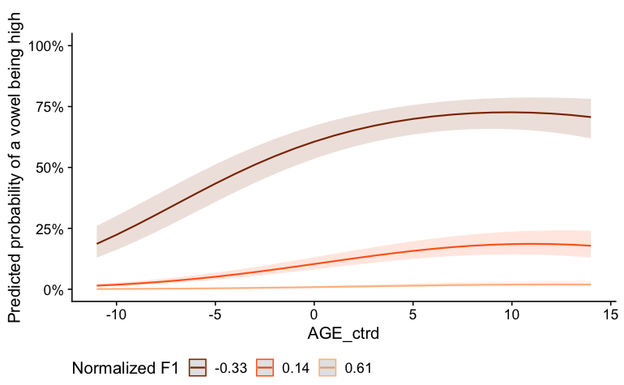

```r
plot_f1_no_child
```

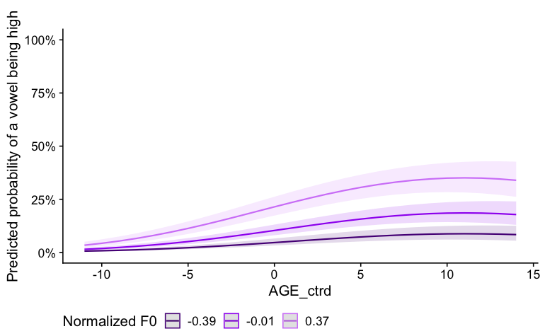

```r
# Create and save plots for F0 without CHILD factor
plot_f0_no_child <- create_plot(
  final_model,
  term1 = NULL,
  term2 = "F0_Regression_Normalized",
  colors = F0_color,
  y_label = "Predicted probability of a vowel being high",
  x_label = "AGE_ctrd",
  legend_title = "Normalized F0"
)
plot_f0_no_child
ggsave("graph/RQ1_plot_F0.png", plot_f0_no_child, width = 8, height = 6, dpi = 300)
```